# Statistical Modelling of Bivariate Extremes

Lecture notes for PhD summer school on “Modelling and statistical analysis of extremes in time series” organised by Thomas Mikosch and Olivier Wintenbeger. October 2023.

Daniela Castro-Camilo

University of Glasgow

# 1 Introduction

Bivariate extreme models are a powerful statistical tools used to analyse extreme values of two related variables simultaneously. These models are particularly valuable in environmental sciences, finance, and risk management, where understanding the joint behaviour of extreme events is essential. By modeling the dependence structure, bivariate extreme models allows us to assess the joint tail behaviour, quantify risk, and make informed decisions.

# 2 Why bivariate extremes?

- Discuss real-world applications: environmental sciences, finance, insurance, and more.
- Illustrate scenarios where simultaneous extreme events matter.
- Slide “Modeling of multivariate extremes” R (342)

# 3 Componentwise maxima

## 3.1 Asymptotic characterisation

Let $(X_1,Y_1),(X_2,Y_2),\ldots$ be a sequence of independent and identically distributed continuous random vectors with distribution $F_{XY}(x,y)$. Let $F_X(x)$ and $F_Y(y)$ be the marginal distributions of $X$ and $Y$, respectively. We define the vector of **componentwise maxima** as
$$\boldsymbol{M}_n = (M_{x,n},M_{y,n}) =
(\max_{i=1,\ldots,n}{X_i},\max_{i=1,\ldots,n}{Y_i}).$$
The index $j$ for which the maximum of the $X_i$ sequence occurs is not necessarily the same index $k$ for which the maximum of the $Y_i$ sequence occurs. To see this, the following R code generates $N\times n = 20\times100=2,000$ samples from $X$ and $Y$ ($X\perp Y$) following Gaussian distributions and construct the componentwise maxima vector using blocks of size $n=100$.

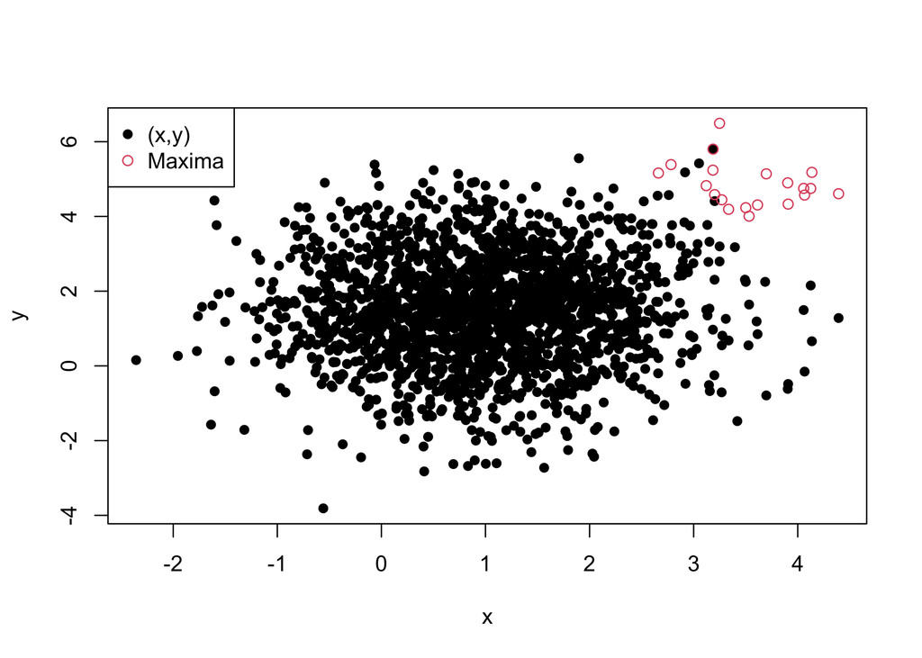

```r
library(mvtnorm)
N = 20 # number of maxima
n = 100 # block size
set.seed(191023)
xy = rmvnorm(N*n, mean = c(1,1.5), sigma = matrix(c(1,0,0,2), ncol=2))
plot(xy, pch = 16, xlab = 'x', ylab = 'y')
max.x = max.y = rep(NA, N)
for(i in 0:(N-1)){
  tmp = xy[(i*n+1):((i+1)*n), ]
  max.x[i+1] = max(tmp[,1])
  max.y[i+1] = max(tmp[,2])
}
points(max.x, max.y, col = 2)
legend('topleft', c('(x,y)', 'Maxima'), col = 1:2, pch = c(16,1))
```

We can see that some componentwise maxima coincide with the bivariate observations, but not all.

As in the univariate case, the asymptotic theory of bivariate extremes starts by studying the limiting behaviour of $\boldsymbol{M}_n$. Since $X$ and $Y$ are independent, we know that the three-types theorem applies to $M_{x,n}$ and $M_{y,n}$ if the necessary normalising sequences exist such that the limiting distribution of renormalised maxima is non-degenerate. When characterising the limiting behaviour of random vectors, it is standard practice to assume some common marginal distribution for each component. By means of the probability integral transform theorem$^{\boldsymbol{(1)}}$, we can always assume virtually any distribution we want, and here we assume that both $X$ and $Y$ follow a standard Fréchet distribution, i.e., cdf
$$F_X(z) = F_Y(z) =
F_\text{Fréchet}(z)= \exp(-1/z),\quad z>0.$$
In that case, it is possible to show that the random variables
$$\begin{equation}\label{eq:cw_smaxima}
M_{x,n}^\star = \frac{\max_{i=1,\ldots,n}{X_i}}{n},\quad M_{y,n}^\star =
\frac{\max_{i=1,\ldots,n}{Y_i}}{n}
\end{equation}$$
also follow a standard Fréchet distribution.

Optional material

Read the following if you want to know more about the use of the probability integral transform to obtain standard Fréchet random variables. If not interested, skip to the next section.

$^{\boldsymbol{(1)}}$: the probability integral transform states that if $Z$ has continuous distribution $F_Z$, then $U = F_Z(Z)$ follows a uniform distribution. So we can transform $Z$ to a random variable $W$ with the desired standard Fréchet distribution by defining $W = F_\text{Fréchet}^{-1}(U)$. Indeed, note that
$$F_{W}(z) = \text{Pr}(W \leq z)
= \text{Pr}(F_\text{Fréchet}^{-1}(U) \leq z) = \text{Pr}(U \leq
F_\text{Fréchet}(z)) = F_\text{Fréchet}(z),$$
in other words, the cdf of $W$ is $F_\text{Fréchet}$ (the Fréchet distribution). In real-data applications, we don’t usually know $F_Z$ so a common practice is to use its empirical distribution (`ecdf`). The following example illustrates how we can use the above results:

```r
G = function(x){
  stopifnot(x>0)
  exp(-1/x)
}
Ginv = function(p){
  if(p>0 & p<1)
    return(-1/log(p))
  else
    return(NA)
}
z = rnorm(100, sd = 10)
U = ecdf(z)(z) # we assume we don't know that z is normally distributed
W = sapply(U, Ginv)

# Does W follows a std Frechet distribution? H0: W ~ stdF
library(evd)
ks.test(W, pfrechet)
```

### 3.1.1 The bivariate extreme value distribution

Let $\boldsymbol{M}_n^\star = (M_{x,n}^\star, M_{y,n}^\star)$ with $M_{x,n}^\star$ and $M_{y,n}^\star$ defined as in $\eqref{eq:cw_smaxima}$. Then if
$$\text{Pr}(M_{x,n}^\star\leq x, M_{y,n}^\star\leq
y)\overset{\mathcal{d}}\rightarrow G(x,y),$$
where $G$ is a non-degenerate distribution, then $G$ is called the **bivariate extreme value distribution** and has the form
$$G_H(x,y) = \exp\{-V_H(x,y)\},\quad x,y>
0,$$
where
$$V_H(x,y)
= 2\int_0^1\max\left(\frac{w}{x},\frac{1-w}{y}\right)\text{d}H(w),$$
is called **exponent measure** and $H$ is the **spectral distribution** function defined in $[0,1]$ satisfying the mean constraint
$$\int_0^1w\text{d}H(w) =
\frac{1}{2}.$$

**Remarks**

1. Note that the subscript in $G_H$ indicates that there is a family of limiting distributions (indexed by $H$). Since $H$ is a distribution, the above means that there are **infinite possible limits**. This is very different from the univariate case where the family of GEV distributions can be characterised by a finite number of parameters.
2. Assuming standard Fréchet margins **is a choice**, meaning that other margins can be assumed. In general, we can apply increasing affine transformations to each margin and consider the sequence of random vectors
   $$\left(\frac{M_{x,n}-b_{x,n}}{a_{x,n}},\frac{M_{y,n}-b_{y,n}}{a_{y,n}}\right)$$
   As in the univariate case, the specific form of the normalising constant $a_{x,n}, b_{x,n},a_{y,n}$ and $b_{y,n}$ will depend on the distribution of the original variables $X_i, Y_i$.
3. If $H$ is differentiable, the spectral density is denoted by $h(w) = \frac{\text{d}H(w)}{\text{d} w}$.

**Exercise 1.** How can we express $H$ as a function of $A$?

**Exercise 2.** Show the max-stability property: ${G_H(tx, ty)}^t = G_H(x,y)$, for $x,y,t>0$.

# 4 Coefficients of extremal dependence

The main goal of bivariate extremes is characterising the extremal dependence between variables. Before we go any further with describing extremal dependence, let’s study the two boundary cases of dependence: independence and perfect dependendence.

- **Case of independence.** This case arises when $H$ places equal mass at the boundary, i.e., $H(0) = H(1) = 0.5$. In that case
  $$V_H(x,y) =
  2\left\{0.5\times\max\left(\frac{0}{x},\frac{1}{y}\right) +
  0.5\times\max\left(\frac{1}{x},\frac{0}{y}\right) \right\} = \frac{1}{y}
  + \frac{1}{x}$$
  The corresponding bivariate extreme value distribution is
  $$G(x,y) = \exp\{-(x^{-1} +
  y^{-1})\} = \exp\{-x^{-1}\}\times \exp\{-y^{-1}\} = F_X(x)\times F_Y(y)
  = F_\text{Fréchet}(x)\times F_\text{Fréchet}(y).$$
  And $A(w) = 1,\quad\forall w\in[0,1].$

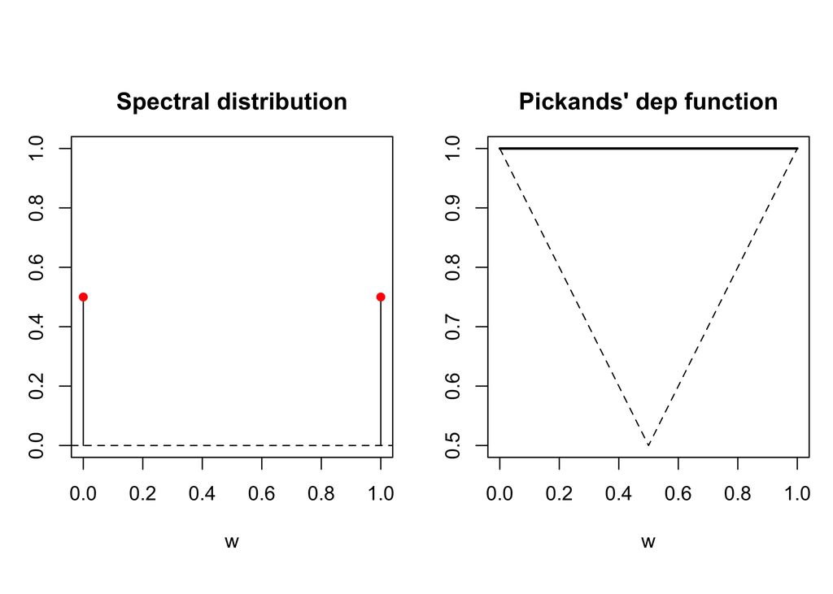

- **Exercise 3.** **Case of perfect dependence**. This case arises when $H$ places unit mass on $w=0.5$. Obtain expressions for $V_H, G_H$ and $A_H$.

Studying the functions $G_H$, $V_H$, $A_H$ and $H$ to understand the level of dependence between $X$ and $Y$ might not be very convenient from a practical point of view. Below, we provide easily interpretable coefficients to characterise the level of extremal dependence of pairs of variables.

## 4.1 The measure $\chi$

One way to measure the strength of extremal dependence is through the limiting conditional probability
$$\chi =
\lim_{u\to 1}\text{Pr}\{F_X(X)>u\mid F_Y(Y)>u\}.$$
Intuitively, $\chi$ is the probability that $X$ is extreme given that $Y$ is extreme. Clearly, $0\leq\chi\leq1$ and we have the following cases:

- If $\chi = 0$, the variables $X$ and $Y$ are said to be **asymptotically independent (AI)**.
- If $\chi > 0$, the variables $X$ and $Y$ are said to be **asymptotically dependent (AD)**. Moreover, the value of $\chi$ increases with the strength of dependence at extreme levels.

If $\chi > 0$ extremes can occur together in the limit, and if $\chi = 0$ they cannot. But $X$ and $Y$ can still be dependent at any finite levels (even very high ones!).

In practice, we cannot always compute $\chi$ (at least not easily), so we instead approximate it. Let
$$\chi(u) = 2 -
\frac{\log\text{Pr}\{F_X(X)\leq u, F_Y(Y)\leq u\}}{\log u}.$$
Then it can be shown that $\chi = \lim_{u\to1}\chi(u)$ and that $2-\log(2u-1)/\log u\leq \chi(u)\leq 1$. Note that $\chi(u)$ can be negative, and its sign determines whether $X$ and $Y$ are negatively or positively associated at the level $u$.

## 4.2 The measure $\bar\chi$

When $X$ and $Y$ are asymptotically independent, $\chi$ and $\chi(u)$ fail to provide any measure of the level of extremal dependence. So for AI variables, we have the quantity
$$\bar\chi(u) =
\frac{2\log(1-u)}{\log\text{Pr}\{F_X(X)>u,F_Y(Y)>u\}}-1.$$
The limit of $\bar\chi(u)$ when $u\to1$ is denoted $\bar\chi$ and we have that $-1\leq\bar\chi\leq1.$

## 4.3 Comments on asymptotic dependence and independence

1. The pair of coefficients $(\chi,\bar\chi)$ and their finite-sample counterparts, $(\chi(u),\bar\chi(u))$, are very useful to determine the type of asymptotic dependence:
   - $\chi>0$ and $\bar\chi=1$: AD $\Rightarrow$ $\chi$ reflects strength of extremal dependence.
   - $\chi=0$ and $\bar\chi<1$: AI $\Rightarrow$ $\bar\chi$ reflects strength of extremal dependence.
2. For statistical modelling, the type of asymptotic dependence assumed has a severe impact on extrapolation into the joint upper tail:
   - If AI is assumed, but the data are in fact AD, the joint occurrence probability of extremes will likely be **underestimated**.
   - If AD is assumed, but data are in fact AI, the joint occurrence probability of extremes will likely be **overestimated**.
   - In terms of risk management, assuming AD when data are AI might not be as bad as assuming AI when data are AD. In general, AD can be interpreted as a fairly conservative approach, which provides upper bounds on the joint occurrence probabilities of extremes.
3. Some known cases:
   - Bivariate Gaussian vectors with correlation $\rho<1$ always have $\chi=0$, i.e., they are AI.
   - On the contrary, bivariate Student t vectors with finite degrees of freedom are AD.
   - Bivariate max-stable distributions (*a.k.a.*, the bivariate GEVD family) are developed under the framework of bivariate regular variation and are, therefore, AD as well.

**Exercise 4.** The following figures show plots of $\chi(u)$ and $\bar\chi(u)$ for bivariate Gaussian, Student t and max-stable vectors. Can you recognise to what curve does each model correspond?

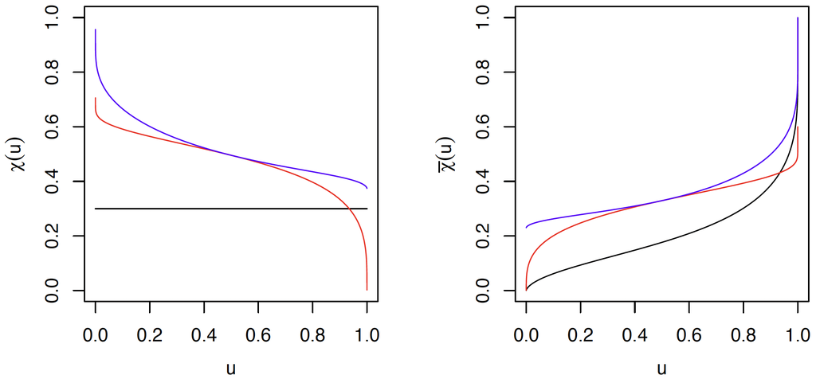

Gaussian is red, student t is blue and max-stable is black.

**Exercise 5.** We can use the function `chiplot` in the library `evd` to estimate $\chi(u)$ and $\bar\chi(u)$ non-parametrically. Check the implementation by generating $N=2000$ copies of bivariate Gaussian vectors with correlation 0.6. Repeat the above now generating copies of zero-mean bivariate Student t vectors with 3 degrees of freedom and diagonal scale matrix.

# 5 Bivariate extremes in practice

We saw in the previous section that the bivariate extreme value distribution $G_H$ arises as the unique limiting family of distributions for properly renormalised vector of componentwise maxima. But since there is a one-to-one map between the spectral distribution $H$ and $G_H$, there are **infinite possible forms for $G_H$** (any distribution function on $[0,1]$ satisfying the mean constraint gives rise to a valid limit). So how can we use this very powerful and elegant mathematical result for statistical modelling? Well, in general, there are three possible strategies:

1. We restrict ourselves to parametric representations of $H$ (and therefore, of $G_H, V_H, A_H$).
2. Use semi-parametric techniques
3. Use non-parametric techniques the estimate the dependence structure

## 5.1 Parametric bivariate models

The goal here is to use parametric sub-families of distributions for either $H, V$ or $A$. This means that $G_H$ can be now described through a finite set of parameters, which greatly simplifies inference, at the cost of reducing model flexibility. In the following, we provide a (non-exhastive) list of parametric models that have been proposed thoughout the years.

1. **Logistic model.** One of the simplest parametric bivariate models, with exponent measure
   $$V(x,y) = \left(x^{-1/\alpha} +
   y^{-1/\alpha}\right)^{\alpha}, \quad \alpha\in(0,1]$$
2. **Asymmetric logistic model.** An extension of the previous model with two additional parameters that allow for asymmetry in the dependence structure:
   $$V(x,y) =
   \frac{1-\psi_1}{x} + \frac{1-\psi_2}{y} +
   \left\{\left(\frac{x}{\psi_1}\right)^{-1/\alpha} +
   \left(\frac{y}{\psi_2}\right)^{-1/\alpha}\right\}^\alpha,\quad
   \alpha\in(0,1], \psi_1,\psi_2\in [0,1]$$
3. **Bilogistic model.** Another extension to the logistic model, with exponent measure given by
   $$V(x,y) = \frac{u^{1-\alpha}}{x} +
   \frac{(1-u)^{1-\beta}}{y},\quad\alpha,\beta>0,$$
   where $u$ is the solution of $(1-\alpha)x^{-1}(1-u)^{\beta} - (1-\beta)y^{-1}u^\alpha = 0.$
4. **Dirichlet model.** An alternative asymmetric model with exponent measure
   $$V(x,y) =
   \frac{1-\text{B}(t;\alpha+1,\beta)}{x} +
   \frac{1-\text{B}(t;\alpha,\beta+1)}{y},$$
   where $\text{B}(t;a,b)$ is the Beta distribution function with parameters $a$ and $b$, evaluated at $t = \alpha x/(\alpha x + \beta y).$
5. **Hüsler-Reiss model.** For $a>0$,
   $$V(x,y) =
   \frac{1}{x}\Phi\left\{\frac{a}{2}-\frac{1}{a}\log\left(\frac{x}{y}\right)\right\}
   +
   \frac{1}{y}\Phi\left\{\frac{a}{2}-\frac{1}{a}\log\left(\frac{y}{x}\right)\right\}$$
6. **Schlater model.** For $\rho\in[-1,1]$,
   $$V(x,y) = \frac{1}{2}\left(\frac{1}{x} +
   \frac{1}{y}\right)\left\{1+\frac{1}{x+y}(x^2 - 2xy\rho +
   y^2)^{1/2}\right\}$$

**Exercise 4.**

## 5.2 Maximum likelihood inference for parametric $G$

It can be shown that the density associated to the bivariate extreme value distribution $G$ is
$$g(z_1,z_2) = \frac{\partial^2
G(z_1,z_2)}{\partial z_1\partial z_2} = \{V_{1}(z_1,z_2)V_2(z_1,z_2) -
V_{12}(z_1,z_2)\}\exp\{-V(z_1,z_2)\},\quad z_1,z_2>0,$$
where the subscripts in $V_1, V_2$ and $V_{12}$ denote partial differentiation with respect to $z_1$ and/or $z_2$. If $(\boldsymbol{z}_{1},\boldsymbol{z}_{2}) = ((z_{1,1},z_{2,1}),\ldots,(z_{1,n},z_{2,n}))$ is a sample of $G$ of size $n$, The log-likelihood is given by
$$\ell(\theta;\boldsymbol{z}_{1},\boldsymbol{z}_{2})
= \sum_{i=1}^n\log\{V_{1}(z_{1,i},z_{2,i})V_2(z_{1,i},z_{2,i}) -
V_{12}(z_{1,i},z_{2,i})\} - V(z_{1,i},z_{2,i}),$$
where $\theta$ is the vector that parametrises $G$. Solutions to the likelihood equations $\frac{\partial\ell(\theta;\boldsymbol{z}_{1},\boldsymbol{z}_{2})}{\partial\theta}\mid_{\theta=\hat\theta} = 0$ do not usually have closed form, so the maximum likelihood estimator is obtained by numerically maximising $\ell(\theta;\boldsymbol{z}_{1},\boldsymbol{z}_{2})$.$^{\boldsymbol{(2)}}$

$^{\boldsymbol{(2)}}$: Since we are talking about the likelihood equations, we are implicitly assuming that they are well defined, i.e., the parametric models fo $G$ are *well-behaved*. In particular, the support of the distribution does not depend on the parameter vector $\theta$.

## 5.3 Return levels

## 5.4 Diagnostics tools

Plots

## 5.5 Inference for parametric $G$

The following can be considered a *cooking recipe* to perform parametric inference based on block maxima.

1. Suppose that we observe $(X_1,Y_1),\ldots,(X_N,Y_N)$.
2. Choose a block size, say of length $n$ and extract the block maximum for each component. Let $\{Z_{1,1},\ldots,Z_{1,n}\}$ and $\{Z_{2,1},\ldots,Z_{2,n}\}$ denote the collection of block maxima for $X$ and $Y$, respectively.
3. Fit marginal GEV distributions to each component and obtain fitted GEV parameters $(\hat\mu_i,\hat\sigma_i\hat\xi_i)$, $i = 1,2.$
4. Using the fitted parameters in step 3, transform the variables to a standard Fréchet scale using
   $$\tilde{Z}_i =
   \left\{1 +
   \hat\xi_i\left(\frac{Z_{i,j}-\hat\mu_i}{\hat\sigma_i}\right)\right\}^{1/\hat\xi_i},\quad
   i=1,2,\text{ and } j = 1,\ldots,n.$$
5. Fit a suitable bivariate extreme parametric model to $(\tilde{Z}_{1,1},\tilde{Z}_{2,1}),\ldots,(\tilde{Z}_{1,n},\tilde{Z}_{2,n})$

# 6 Applications

In this section we will test what we have learned about bivariate models for extremes using simulations and real data.

## 6.2 Case studies

### 6.2.1 Stationary margins

### 6.2.2 Non-stationary margins

# 7 Regression models for bivariate extremes

## 7.1 Parametric regression models

## 7.2 Semi-parametric regression models

# 8 Comments: sometimes, it all boils down to bivariate analysis, even when you are working with higher dimensions (talk about pairwise likelihood, and summary measures)